# Assessing Pregnancy Risk: ML Modeling and Evaluation

DA5030

Kaustubh Pachpande

Summer 2024

# 1 Introduction

Pregnancy represents a significant and transformative period in a woman’s life. However, it also entails various risks and challenges for both the mother and her unborn child. Accurately predicting and managing these risks is essential for ensuring a safe and healthy pregnancy, which is the aim of this project.

## 1.1 Project Objective

The primary objective of this project is to develop a predictive model to assess the ‘Risk Level’ of maternal health based on various health indicators (or physiological factors like age, blood sugar, body temp etc). By accurately predicting ‘Risk levels’, healthcare providers can take timely and appropriate actions to mitigate risks, thus improving maternal health outcomes.

## 1.2 Business Goals

1. **Improve Maternal Health Outcomes**: By identifying high-risk pregnancies early, healthcare providers can offer targeted interventions, thereby reducing maternal mortality rates.
2. **Support Decision Making**: Provide healthcare professionals with a reliable tool to aid in decision-making processes related to maternal health.

## 1.3 Success Criteria

The success of this project will be evaluated based on the following criteria:

1. **Accuracy of Predictions**: The predictive model should achieve a high level of accuracy in classifying the risk levels (low, mid, high).
2. **Practical Applicability**: The model should be easy to interpret and implement.
3. **Improvement in Health Outcomes**: Ultimately, this project would be deemed successful after a demonstrable improvement in maternal health outcomes as a result of implementing the predictive model.

## 1.4 Dataset Description

The dataset used for this project is in CSV format and was obtained from - [here](https://archive.ics.uci.edu/dataset/863/maternal+health+risk) ie., the UCI Machine Learning Repository. The dataset contains health records collected from various hospitals, community clinics, and maternal health care centers through an IoT-based risk monitoring system. It includes 1014 instances with the following features:

- **Age**: Age of the patient
- **SystolicBP**: Systolic Blood Pressure
- **DiastolicBP**: Diastolic Blood Pressure
- **BS**: Blood Sugar
- **BodyTemp**: Body Temperature
- **HeartRate**: Heart Rate
- **RiskLevel**: Risk level of Maternal health (target variable)

The target variable ‘Risklevel’ has 3 classes namely “low risk”, “mid risk”, and “high risk”.

# 2 Installing Required Packages

We will first check if the packages required for the project are installed, and if not we proceed to install them.

# 3 Data Acquisition

Next, we load the data set from a URL and then import it into a data frame using the `read.csv` function.

```
##   Age SystolicBP DiastolicBP BS BodyTemp HeartRate RiskLevel
## 1  25        130          80 15       98        86 high risk
## 2  35        140          90 13       98        70 high risk
## 3  29         90          70  8      100        80 high risk
```

We can see that the CSV file was successfully imported into a data frame. Next, we proceed to explore the data set.

# 4 Data Exploration

## 4.1 Data Structure Overview

We first inspect the data set using `str()` and `summary()`

```r
str(mat_df)
```

```
## 'data.frame':    1014 obs. of  7 variables:
##  $ Age        : int  25 35 29 30 35 23 23 35 32 42 ...
##  $ SystolicBP : int  130 140 90 140 120 140 130 85 120 130 ...
##  $ DiastolicBP: int  80 90 70 85 60 80 70 60 90 80 ...
##  $ BS         : num  15 13 8 7 6.1 7.01 7.01 11 6.9 18 ...
##  $ BodyTemp   : num  98 98 100 98 98 98 98 102 98 98 ...
##  $ HeartRate  : int  86 70 80 70 76 70 78 86 70 70 ...
##  $ RiskLevel  : Factor w/ 3 levels "high risk","low risk",..: 1 1 1 1 2 1 3 1 3 1 ...
```

```r
summary(mat_df)
```

```
##       Age          SystolicBP     DiastolicBP           BS
##  Min.   :10.00   Min.   : 70.0   Min.   : 49.00   Min.   : 6.000
##  1st Qu.:19.00   1st Qu.:100.0   1st Qu.: 65.00   1st Qu.: 6.900
##  Median :26.00   Median :120.0   Median : 80.00   Median : 7.500
##  Mean   :29.87   Mean   :113.2   Mean   : 76.46   Mean   : 8.726
##  3rd Qu.:39.00   3rd Qu.:120.0   3rd Qu.: 90.00   3rd Qu.: 8.000
##  Max.   :70.00   Max.   :160.0   Max.   :100.00   Max.   :19.000
##     BodyTemp        HeartRate        RiskLevel
##  Min.   : 98.00   Min.   : 7.0   high risk:272
##  1st Qu.: 98.00   1st Qu.:70.0   low risk :406
##  Median : 98.00   Median :76.0   mid risk :336
##  Mean   : 98.67   Mean   :74.3
##  3rd Qu.: 98.00   3rd Qu.:80.0
##  Max.   :103.00   Max.   :90.0
```

Some important observations include: 1. Data frame has 1014 observations and 7 features (including target variable). 2. All predictor variables are continuous features. 3. `str` shows The target variable having levels as high-low-mid to be 1-2-3. We will level them appropriately as low-mid-high to be 1-2-3 so that the ordering matches the intended ordinal relationship. 3. The `summary` function shows no missing values. We will confirm this during Data preparation. 4. The minimum ‘HeartRate’ is shown to be 7, which is not possible. This might be a data entry error and we need to identify these observations and handle them either via deletion/imputation. 5. The minimum ‘Age’ is shown to be 10, and maximum age to be pregnant is shown to be 70. This might be possible in rare cases, but would still be uncommon. We will not impute these values as they might be true.

## 4.2 Data Exploratory Plots

1. Using a pie chart, we will first check how classes within the target variable are proportioned.
2. After that we will use box plots for outlier analysis of continuous features. We will further check the number of outliers for each continuous column.
3. We will use`pairs.panels` function to check for correlation and collinearity between features, and use Shapiro Wilk test to determine normality of the data.

### 4.2.1 Distribution of Target Variable

Comparing the different classes of Pregnancy Risk levels (Low risk, Mid risk, High risk) using a pie chart:

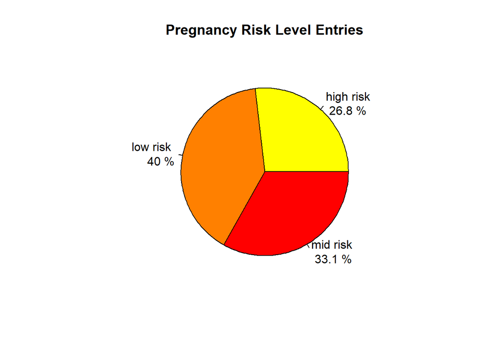

### 4.2.2 Detecting Outliers in the Data Set

We will analyze continuous features using box plots to check for outliers:

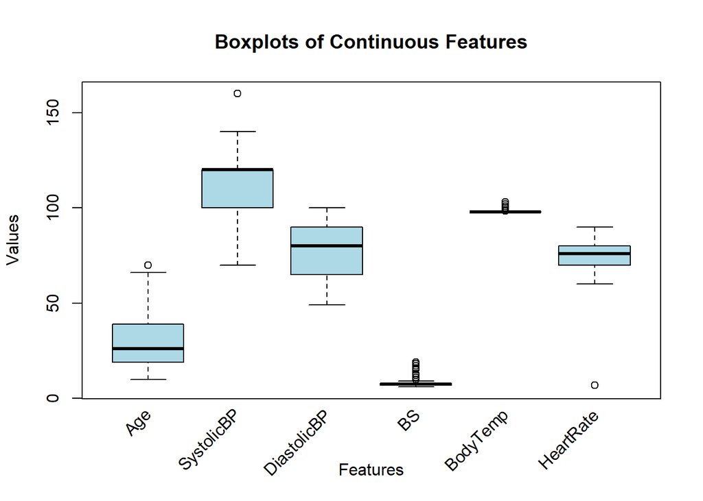

We notice that ‘BS’ (Blood Sugar) and ‘BodyTemp’ have many outliers. Additionally. ‘HeartRate’ can be seen to have an outlier which probably relates to the minimum value of 7 as identified earlier.

We will draw boxplots of ‘BS’ (Blood Sugar) and ‘BodyTemp’ individually for better clarity:

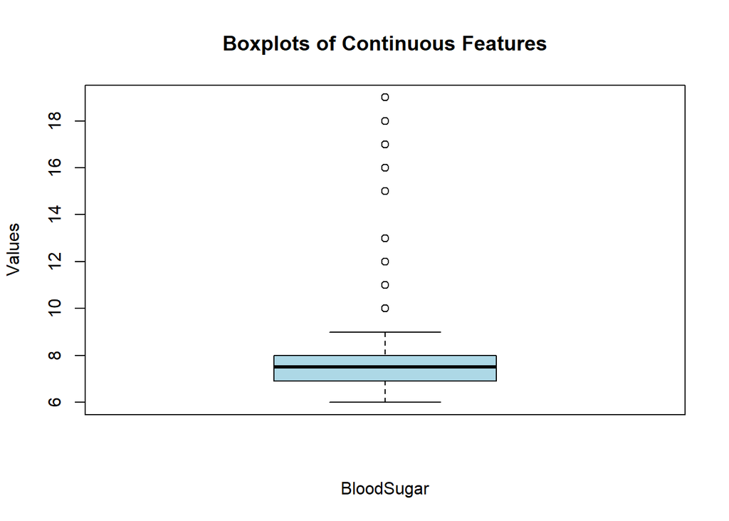

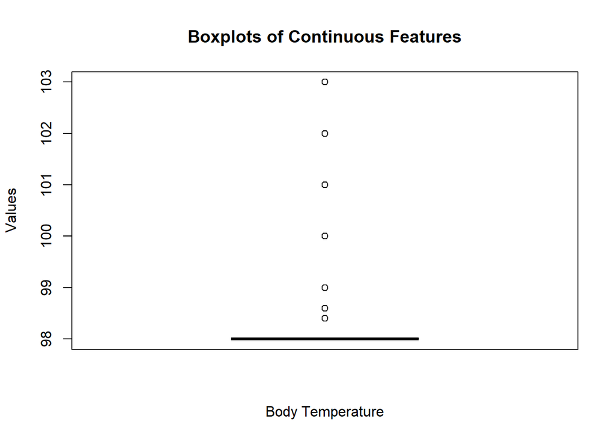

We can notice that there are many outliers for both of these columns. As the predictor features represent physiological data, these values can have abnormal values in rare cases, which might have a significant effect on the target variable.

We will further identify the number of outliers for each column by assuming that any value that deviates from mean by more than 3 standard deviations is an outlier.

```
## [1] "Age Column has 0 outliers"
## [1] "SystolicBP Column has 0 outliers"
## [1] "DiastolicBP Column has 0 outliers"
## [1] "BS Column has 22 outliers"
## [1] "BodyTemp Column has 13 outliers"
## [1] "HeartRate Column has 2 outliers"
```

We observe that ‘BS’ column (ie., Blood Sugar) and ‘BodyTemp’ have a 22 and 13 outliers respectively. ‘HeartRate’ column has 2 outliers which most probably represent the erroneous minimum value of 7. We will handle these during Data Preparation.

### 4.2.3 Correlation & Collinearity

Next, we analyze our data using `pairs.panels()` to check for correlations between individual features, and identify which predictor features are highly correlated.

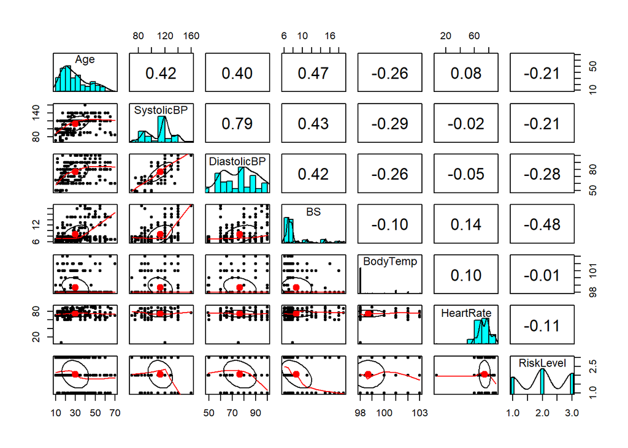

```r
pairs.panels(mat_df)
```

We notice that out of all the predictor features, ‘SystolicBP’ and ‘DiastolicBP’ are highly correlated to each other. This can be an issue for logistic regression models. We will combine them to create a new derived feature which will eliminate the correlation and better represent both the features.

We also observe that almost all features show skew in their distribution. Additionally, ‘BodyTemp’ shows an almost dominant single value in it’s distribution. We will explore this further. First, we will visually inspect normality of each column using histograms and determine normality using the Shapiro-Wilk test.

### 4.2.4 Evaluation of Distribution

Inspecting normality visually using histograms:

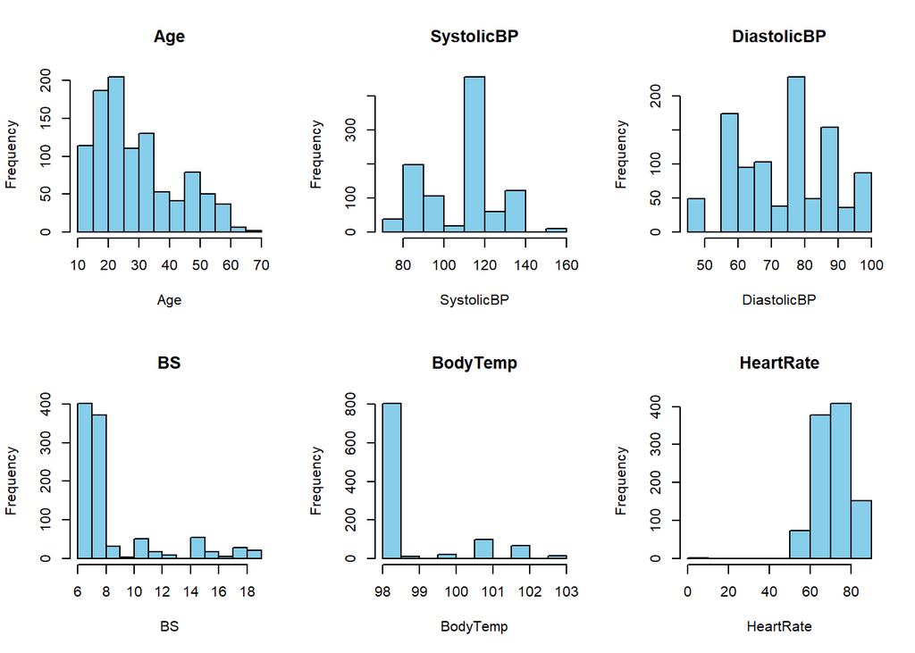

We can observe that all distributions show skew, and that none of them can be considered fairly normal. We also notice that ‘BodyTemp’ is dominated by values that occupy the minimum value of the column. This might make it harder to transform it to a normal distribution as any transformed distribution will have a single dominant value.

We proceed to determine normality of each column using the Shapiro-Wilk test.

```
## [1] "Column named: Age is non normal as determined by the Shapiro Wilk test"
## [1] "Column named: SystolicBP is non normal as determined by the Shapiro Wilk test"
## [1] "Column named: DiastolicBP is non normal as determined by the Shapiro Wilk test"
## [1] "Column named: BS is non normal as determined by the Shapiro Wilk test"
## [1] "Column named: BodyTemp is non normal as determined by the Shapiro Wilk test"
## [1] "Column named: HeartRate is non normal as determined by the Shapiro Wilk test"
```

We can see that using the Shapiro-Wilk test, none of the features are normally distributed. We will transform these features during the data preparation step using log, inverse, square-root, or box-cox transformation and attempt to normalize the distribution.

# 5 Data Cleaning & Shaping

Next, we proceed to data cleaning and shaping. We will first rename levels appropriately as low risk - mid risk - high risk so that the ordering matches the intended ordinal relationship.

```r
mat_df$RiskLevel <- factor(mat_df$RiskLevel,
                           levels = c("low risk", "mid risk", "high risk"))
```

Next we will identify and remove duplicates, if any, from the data frame:

```r
# Identifying duplicates (not including first occurence)

dup_df <- duplicated(mat_df)

# Identifying number of duplicates

total_dup <- nrow(mat_df[dup_df,])

# Creating new data frame without duplicates

mat_df_uniq <-  unique(mat_df)
```

We notice that the data frame has 562 duplicates. This is a significant number of duplicates which should be removed to prevent it from affecting any analysis. We thus create a data set called ‘mat_df_uniq’ which has no duplicates.

Further in the project, we will create two more data sets to have a total of three data sets: 1. ‘mat_df_uniq’ - Original data set without any imputations 2. ‘mat_df_io’ - containing Imputed Outliers, and 3. ‘mat_df_im’ - containing Imputed Missing values.

The objective of creating ‘mat_df_io’ and comparing it with the original ‘mat_df_uniq’ data set is because in a health care setting the values shown as outliers can be very significant in determining the target variable and thus shouldn’t be tampered with. We will still impute them and compare it with original.

The objective of creating ‘mat_df_im’ and comparing it with the original ‘mat_df_uniq’ data frame is because during data exploration we could identify that there were no missing values. We will thus randomly introduce missing values and impute them appropriately, and then compare it with the original data frame to see any effect of random imputations.

## 5.1 Handling Outliers

As identified during Data Exploration, outliers were present in ‘BS’ (BloodSugar), ‘BodyTemp’, and ‘HeartRate’. The values might change after we removed the duplicates. We will again identify the outliers and handle them appropriately:

```
## [1] "Age Column has no outliers"
## [1] "SystolicBP Column has no outliers"
## [1] "DiastolicBP Column has no outliers"
## [1] "BS Column has 15 outliers having values - 18,18,18,17,18,19,18,19,18,18,19,18,18,18,18"
## [1] "BodyTemp Column has 9 outliers having values - 103,103,103,103,103,103,103,103,103"
## [1] "HeartRate Column has 1 outliers having values - 7"
```

1. We see that the number of outliers have lessened in number.
2. Additionally, outlier of ‘HeartRate’ column is indeed the erroneous value of 7. We will impute this with the median in the original dataset (mat_df_uniq).
3. Regarding outliers of ‘BS’ (BloodSugar) and ‘BodyTemp’, we will create another dataset ‘mat_df_io’ where we Impute Outliers of these two columns with the median (imputation done with median since the distribution for both these columns isn’t normal).

```
##   Age SystolicBP DiastolicBP BS BodyTemp HeartRate RiskLevel
## 1  25        130          80 15       98        86 high risk
## 2  35        140          90 13       98        70 high risk
## 3  29         90          70  8      100        80 high risk
```

We have thus created our second dataframe ‘mat_df_io’ as shown above, which has Imputed Outliers.

## 5.2 New Derived Features

During data exploration, we noticed that ‘SystolicBP’ and ‘DiastolicBP’ were highly correlated. We will combine these two to derive a new feature called ‘Mean Aterial Pressure (MAP)’. ‘MAP’ will give a single value that reflects overall arterial pressure over a cardiac cycle. It is given by the formula,

$$\text{MAP} = \text{DBP} + \frac{1}{3} (\text{SBP} - \text{DBP})$$
where, MAP = Mean Arterial Pressure SBP = Systolic Blood Pressure DBP = Diastolic Blood Pressure

```
##   Age    MAP BS BodyTemp HeartRate RiskLevel
## 1  25  96.67 15       98        86 high risk
## 2  35 106.67 13       98        70 high risk
## 3  29  76.67  8      100        80 high risk
```

```
##   Age    MAP BS BodyTemp HeartRate RiskLevel
## 1  25  96.67 15       98        86 high risk
## 2  35 106.67 13       98        70 high risk
## 3  29  76.67  8      100        80 high risk
```

We can observe that ‘SystolicBP’ and ‘DiastolicBP’ (which were highly correlated) were combined to derive a new feature called ‘MAP’ (Mean Arterial Pressure) in both data sets (‘mat_df_uniq’ and ‘mat_df_io’).

## 5.3 Identification of Missing Values

Next, we proceed to identify missing values. We create a our third data frame ‘mat_df_im’ from ‘mat_df_uniq’ and inspect for missing values :

```
## [1] "column 1 has 0 missing values"
## [1] "column 2 has 0 missing values"
## [1] "column 3 has 0 missing values"
## [1] "column 4 has 0 missing values"
## [1] "column 5 has 0 missing values"
## [1] "column 6 has 0 missing values"
```

We notice that there are no missing values in the data set. We will proceed to randomly introduce missing values, and later compare performance of the algorithms with imputed vs full data.

## 5.4 Data Imputation of Missing Data

Randomly introducing missing values in predictor features of ‘mat_df_im’ data set.

```
##   Age    MAP BS BodyTemp HeartRate RiskLevel
## 1  25  96.67 15       98        86 high risk
## 2  35 106.67 13       98        70 high risk
## 3  29     NA  8      100        80 high risk
```

We notice that missing values have been introduced into the data set. We will identify number of missing values for confirmation.

```
## [1] "column 1 has 45 missing values"
## [1] "column 2 has 45 missing values"
## [1] "column 3 has 45 missing values"
## [1] "column 4 has 45 missing values"
## [1] "column 5 has 45 missing values"
```

We notice that each column has 45 missing values. Having 452 rows, this makes approximately 10 percent (45/452) of each column, which in turn makes 10 percent of the entire data set. We thus have a moderate percentage of data as missing in our data frame.

Before imputing the missing data, we handle outliers of ‘mat_df_im’ by imputing it with median (since data is not normally distributed).

Next, as all columns are continuous, and none of them are normally distributed, we will proceed with imputing the missing data with median of each column.

```
##   Age    MAP BS BodyTemp HeartRate RiskLevel
## 1  25  96.67 15       98        86 high risk
## 2  35 106.67 13       98        70 high risk
## 3  29  90.00  8      100        80 high risk
```

We have successfully imputed the missing values with median for each column.

We now have all three data frames as follows: 1. ‘mat_df_uniq’ : Original data frame having no duplicates (outliers not imputed) 2. ‘mat_df_io’ : Data frame having Imputed Outliers 3. ‘mat_df_im’ : Data frame having Imputed Missing values

We will apply next steps in data preparation (transformation, standardization, PCA, and deriving new features) to all three data sets.

## 5.5 Transformation of Features to Adjust Distribution

We proceed to transform features and bring their distribution as close to a normal distribution as possible. We will first determine skewness using `skewness` function. We will adhere to the generally accepted range of skewness ie., if values are between -0.5 and 0.5 the distribution is considered a fairly symmetrical normal distribution.

We will first determine and transform features of ‘mat_df_uniq’ (Original dataframe with no duplicates).

```r
# Determining skewness of 'mat_df_uniq'

for(i in 1:ncol(mat_df_uniq[,-6])){
  a <- skewness(mat_df_uniq[,i])
  print(paste0(names(mat_df_uniq)[i], " has a skew of ", round(a,2)))
}
```

```
## [1] "Age has a skew of 0.92"
## [1] "MAP has a skew of -0.13"
## [1] "BS has a skew of 2.25"
## [1] "BodyTemp has a skew of 1.74"
## [1] "HeartRate has a skew of 0.04"
```

We see that features ‘Age’, ‘BS’ (Blood Sugar), and ‘BodyTemp’ have values greater than 0.5, while others fall within the desired range. We will try transforming these features using log, sqrt, inverse, or box-cox transformations.

```r
# For 'Age' column

  ## Displaying skewness of 'Age' before transformation

  paste0("Skewness of Age before transformation is: ",
         round(skewness(mat_df_uniq$Age),2))
```

```
## [1] "Skewness of Age before transformation is: 0.92"
```

```r
  ## Applying a log-transform on 'Age' column

  mat_df_uniq$Age <- log(mat_df_uniq$Age)

  ## Displaying skewness of 'Age' after transformation

  paste0("New skewness value for Age after log transform is: ",
         round(skewness(mat_df_uniq$Age),2))
```

```
## [1] "New skewness value for Age after log transform is: 0.2"
```

```r
# For 'BS' (Blood Sugar) column

  ## Displaying skewness of 'BS' (Blood Sugar) before transformation

  paste0("Skewness of BS before transformation is: ",
         round(skewness(mat_df_uniq$BS),2))
```

```
## [1] "Skewness of BS before transformation is: 2.25"
```

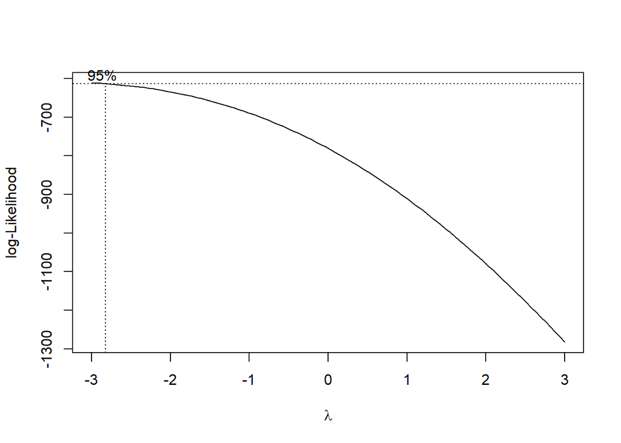

```r
  ## Fitting a linear model (for box-cox transformation)

  lm_bs_uniq <- lm(BS ~ 1, data = mat_df_uniq)

  ## Plotting graph to check values of lambda

  bc_graph_uniq <- boxcox(lm_bs_uniq, seq(-3,3))
```

```r
  ## Extracting the best lambda

  lambda_uniq <- bc_graph_uniq$x[which.max(bc_graph_uniq$y)]

  ## Performing box-cox transformation using best lambda

  mat_df_uniq$BS <- (mat_df_uniq$BS^lambda_uniq - 1) / lambda_uniq

  ## Displaying skewness of 'BS' (Blood Sugar) after transformation

  paste0("New skewness value for BS after box-cox transform is: ",
         round(skewness(mat_df_uniq$BS),2))
```

```
## [1] "New skewness value for BS after box-cox transform is: 0.44"
```

We successfully reduced skewness for ‘Age’ and ‘BS’ (Blood Sugar) to 0.2 and 0.44 respectively. For ‘Age’, we used a log-transform whereas for ‘BS’ (Blood Sugar), we used a box-cox transformation.

Also shown is a graph, which was plotted using the `boxcox` function to determine the optimal lambda value. Using this we were able to transform the ‘BS’ (Blood Sugar) variable and bring it close to a normal distribution.

Regarding ‘BodyTemp’, all transforms were applied and there was no significant reduction in skew. This is probably because most of the values occupy the minimum value of the column. This concern was also raised during Data Exploration.

Next, we determine and transform features of ‘mat_df_io’ (having Imputed Outliers).

```r
# Determining skewness of 'mat_df_io'

for(i in 1:ncol(mat_df_io[,-6])){
  a <- skewness(mat_df_io[,i])
  print(paste0(names(mat_df_io)[i], " has a skew of ", round(a,2)))
}
```

```
## [1] "Age has a skew of 0.92"
## [1] "MAP has a skew of -0.13"
## [1] "BS has a skew of 2.4"
## [1] "BodyTemp has a skew of 1.83"
## [1] "HeartRate has a skew of 0.04"
```

We see that features ‘Age’, ‘BS’ (Blood Sugar), and ‘BodyTemp’ have values greater than 0.5, while others fall within the desired range. We will try transforming these features using log, sqrt, inverse, or box-cox transformations.

```r
# For 'Age' column

  ## Displaying skewness of 'Age' before transformation

  paste0("Skewness of Age is: ", round(skewness(mat_df_io$Age),2))
```

```
## [1] "Skewness of Age is: 0.92"
```

```r
  ## Applying a log-transform on 'Age' column

  mat_df_io$Age <- log(mat_df_io$Age)

  ## Displaying skewness of 'Age' after transformation

  paste0("New skewness value for Age after log transform is: ", round(skewness(mat_df_io$Age),2))
```

```
## [1] "New skewness value for Age after log transform is: 0.2"
```

```r
# For 'BS' (Blood Sugar) column

  ## Displaying skewness of BS (Blood Sugar) before transformation

  paste0("Skewness of BS is: ", round(skewness(mat_df_io$BS),2))
```

```
## [1] "Skewness of BS is: 2.4"
```

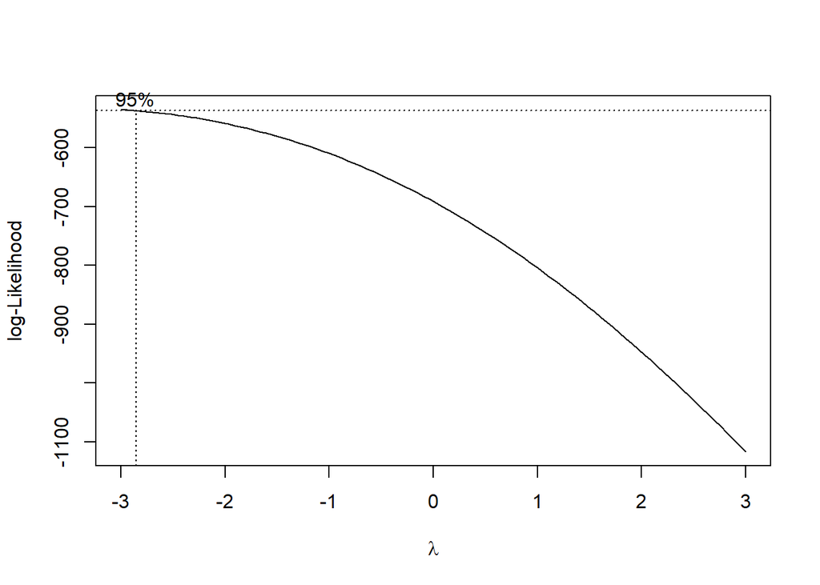

```r
  ## Fitting a linear model (for box-cox transformation)

  lm_bs_io <- lm(BS ~ 1, data = mat_df_io)

  ## Plotting graph to check values of lambda

  bc_graph_io <- boxcox(lm_bs_io, seq(-3,3))
```

```r
  ## Extracting the best lambda

  lambda_io <- bc_graph_io$x[which.max(bc_graph_io$y)]

  ## Performing box-cox transformation using best lambda

  mat_df_io$BS <- (mat_df_io$BS^lambda_io - 1) / lambda_io

  ## Displaying skewness of 'BS' (Blood Sugar) after transformation

  paste0("New skewness value for BS after box-cox transform is: ", round(skewness(mat_df_io$BS),2))
```

```
## [1] "New skewness value for BS after box-cox transform is: 0.4"
```

We successfully reduced skewness for ‘Age’ and ‘BS’ (Blood Sugar) to 0.2 and 0.4 respectively. For ‘Age,’ we again used a log-transform whereas for ‘BS’ (Blood Sugar), we used a box-cox transformation.

The graph shown was plotted using the `boxcox` function to determine the optimal lambda value. Using this we were able to transform the ‘BS’ (Blood Sugar) variable and bring it close to a normal distribution.

Regarding ‘BodyTemp’, similar to previous case, all transforms were applied and there was no significant reduction in skew. This is probably because most of the values occupy the minimum value of the column.

Lastly, we determine skew and transform features of ‘mat_df_im’ (having Imputed Missing values).

```r
# Determining skewness of 'mat_df_im'

for(i in 1:ncol(mat_df_im[,-6])){
  a <- skewness(mat_df_im[,i])
  print(paste0(names(mat_df_im)[i], " has a skew of ", round(a,2)))
}
```

```
## [1] "Age has a skew of 1.02"
## [1] "MAP has a skew of -0.16"
## [1] "BS has a skew of 2.52"
## [1] "BodyTemp has a skew of 1.84"
## [1] "HeartRate has a skew of -0.05"
```

We see that features ‘Age’, ‘BS’ (Blood Sugar), and ‘BodyTemp’ have values greater than 0.5, while others fall within the desired range. We will try transforming these features using log, sqrt, inverse, or box-cox transformations.

```r
# For 'Age' column

  ## Displaying skewness of 'Age' before transformation

  paste0("Skewness of Age is: ", round(skewness(mat_df_im$Age),2))
```

```
## [1] "Skewness of Age is: 1.02"
```

```r
  ## Applying a log-transform on 'Age' column

  mat_df_im$Age <- log(mat_df_im$Age)

  ## Displaying skewness of 'Age' after transformation

  paste0("New skewness value for Age after log transform is: ", round(skewness(mat_df_im$Age),2))
```

```
## [1] "New skewness value for Age after log transform is: 0.23"
```

```r
# For 'BS' (Blood Sugar) column

  ## Displaying skewness of 'BS' (Blood Sugar) before transformation

  paste0("Skewness of BS is: ", round(skewness(mat_df_im$BS),2))
```

```
## [1] "Skewness of BS is: 2.52"
```

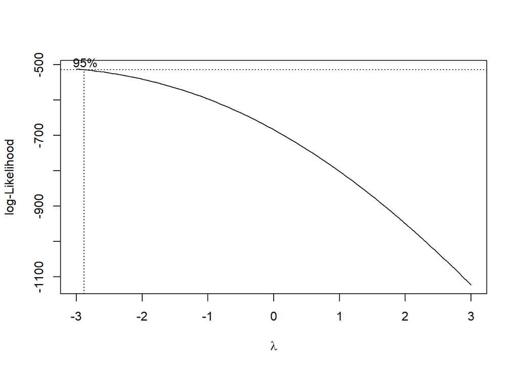

```r
  ## Fitting a linear model (for box-cox transformation)

  lm_bs_im <- lm(BS ~ 1, data = mat_df_im)

  ## Plotting graph to check values of lambda

  bc_graph_im <- boxcox(lm_bs_im, seq(-3,3))
```

```r
  ## Extracting the best lambda

  lambda_im <- bc_graph_im$x[which.max(bc_graph_im$y)]

  ## Performing box-cox transformation using best lambda

  mat_df_im$BS <- (mat_df_im$BS^lambda_im - 1) / lambda_im

  ## Displaying skewness of 'BS' (Blood Sugar) after transformation

  paste0("New skewness value for BS after box-cox transform is: ", round(skewness(mat_df_im$BS),2))
```

```
## [1] "New skewness value for BS after box-cox transform is: 0.5"
```

We successfully reduced skewness for ‘Age’ and ‘BS’ (Blood Sugar) to 0.23 and 0.5 respectively. For ‘Age’, we used a log-transform whereas for ‘BS’ (Blood Sugar), we used a box-cox transformation.

The graph shown was plotted using the `boxcox` function to determine the optimal lambda value. Using this we were able to transform the ‘BS’ (Blood Sugar) variable and bring it close to a normal distribution.

Regarding ‘BodyTemp’, similar to previous 2 cases, all transforms were applied and there was no significant reduction in skew. This is probably because most of the values occupy the minimum value of the column.

## 5.6 Standardization of Feature Values

Next, we standardize data of all 3 data sets using z-score standardization to scale features on a common scale.

```r
# Creating a function to normalize values using z-score standardization

Zscore_norm <- function(x){
  return((x - mean(x))/(sd(x)))
}

# Extracting target variable columns from each data frame

target_uniq <- mat_df_uniq[,6]
target_io <- mat_df_io[,6]
target_im <- mat_df_im[,6]

# Standardizing data frames with normalized values using 'lapply'

mat_df_uniq <- as.data.frame(lapply(mat_df_uniq[,-6], Zscore_norm))
mat_df_io <- as.data.frame(lapply(mat_df_io[,-6], Zscore_norm))
mat_df_im <- as.data.frame(lapply(mat_df_im[,-6], Zscore_norm))

# Combining target variable columns to z-score standardized data frames

mat_df_uniq <- cbind(mat_df_uniq, RiskLevel = target_uniq)
mat_df_io <- cbind(mat_df_io, RiskLevel = target_io)
mat_df_im <- cbind(mat_df_im, RiskLevel = target_im)

# Inspecting data frame

head(mat_df_uniq, 3)
```

```
##          Age        MAP       BS   BodyTemp  HeartRate RiskLevel
## 1 -0.1132665  0.6649446 1.962162 -0.4908068  1.5817436 high risk
## 2  0.6296765  1.3618916 1.812628 -0.4908068 -0.5452869 high risk
## 3  0.2144503 -0.7289496 0.402696  0.9267310  0.7841072 high risk
```

```r
head(mat_df_io, 3)
```

```
##          Age        MAP        BS   BodyTemp  HeartRate RiskLevel
## 1 -0.1132665  0.6649446 2.2015430 -0.4658431  1.5817436 high risk
## 2  0.6296765  1.3618916 2.0394479 -0.4658431 -0.5452869 high risk
## 3  0.2144503 -0.7289496 0.5110785  1.1055082  0.7841072 high risk
```

```r
head(mat_df_im, 3)
```

```
##          Age       MAP        BS   BodyTemp  HeartRate RiskLevel
## 1 -0.1326907 0.6842197 2.2916080 -0.4714631  1.6849455 high risk
## 2  0.6465816 1.4150992 2.1195049 -0.4714631 -0.6016985 high risk
## 3  0.2110511 0.1967230 0.4967718  0.9831534  0.8274540 high risk
```

We can observe that all values for the 3 data sets have been standardized.

To normalize all values, we first created a ‘Zscore_norm’ function which returns the z-scores for a given vector. After this, we separated the target variable from each data frame. Then we standardized each of three data frames where we used `lapply()` to apply the function to all numeric columns. Lastly, we appended the target variable column to the z-score standardized data frames. Thus, the data frames now have all the z-score standardized values from the original data frame.

We normalize all values in the data set because ML algorithms like ‘kNN’ rely on the distances between data points to make predictions. Features having larger scales than others tend to overpower the others and decrease their relevancy. Hence, putting all features on a standardized scale ensures that all features contribute equally.

## 5.7 Feature Encoding

Since all features in the data set used are continuous, encoding the features by one-hot encoding or frequency encoding won’t be required. If there had been a categorical feature, we would have to encode it to numerical values. For ‘kNN’ this is done to ensure distances can be calculated properly, while for ‘logistic regression’ this is done because it requires numeric data input for predictor features.

## 5.8 Identification of Principal Components (PCA)

Next, we perform Principal Component Analysis to identify Principal Components and further use them for modeling. We will perform PCA for all three data sets (mat_df_uniq, mat_df_io, mat_df_im).

First, we start with ‘mat_df_uniq’.

```r
# Performing Principal Component Analysis

pca_uniq <- prcomp(mat_df_uniq[,-6], center = FALSE, scale. = FALSE)

# Inspecting summary of PCA

summary(pca_uniq)
```

```
## Importance of components:
##                           PC1    PC2    PC3    PC4    PC5
## Standard deviation     1.3415 1.0753 0.9327 0.7885 0.7433
## Proportion of Variance 0.3599 0.2313 0.1740 0.1244 0.1105
## Cumulative Proportion  0.3599 0.5912 0.7651 0.8895 1.0000
```

From `summary` function, we observe that after performing PCA on ‘mat_df_uniq’ (original data frame), PC1 explains most variance (36%) out of all the components. Additionally, if we were to keep a threshold of 90%, we would consider the first four components as they explain 89% (~90%) of total variance. But wanting to retain data that explains at least 95% of variance, we will consider all five Principal Components in predicting the target variable.

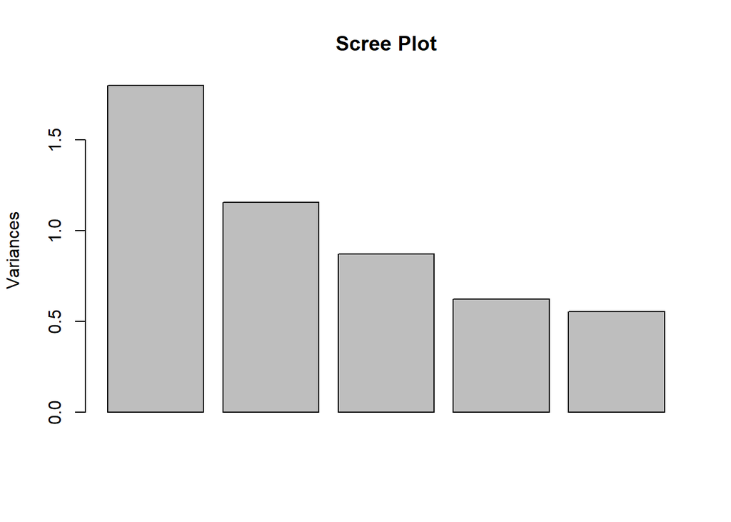

```r
# Scree plot

plot(pca_uniq, main = "Scree Plot")
```

The scree plot for PCA on ‘mat_df_uniq’ shows the variance of each principal component. We observe that highest variance is shown by PC1, after which the curve starts to slope downward. It appears to level off a little bit after the fourth Principal Component. This “elbow” point, beyond which principal components are usually dropped, can be a litle tough to point out for the Scree Plot shown.

We proceed to extract the Principal Components into a data frame and append the target variable to it. This will then be used for model construction and evaluation.

```
##          PC1         PC2          PC3         PC4        PC5 RiskLevel
## 1 -1.5258529 -1.49267724  0.548643843 -1.17298959 -0.9025737 high risk
## 2 -2.0949137  0.09129609 -0.982404116 -0.69489131 -0.4796895 high risk
## 3  0.3070455 -1.33652779  0.003114543 -0.04860954  0.5746467 high risk
```

We observe the five Principal Components selected along with the target variable in the final prepared data set of ‘mat_df_uniq’ called ‘final_uniq’.

We proceed to perform PCA for ‘mat_df_io’ (having Imputed Outliers).

```r
# Performing Principal Component Analysis

pca_io <- prcomp(mat_df_io[,-6], center = FALSE, scale. = FALSE)

# Inspecting summary of PCA

summary(pca_io)
```

```
## Importance of components:
##                           PC1    PC2    PC3    PC4    PC5
## Standard deviation     1.3142 1.1078 0.9327 0.7891 0.7437
## Proportion of Variance 0.3454 0.2454 0.1740 0.1245 0.1106
## Cumulative Proportion  0.3454 0.5909 0.7649 0.8894 1.0000
```

From `summary` function, we observe that after performing PCA on ‘mat_df_io’ (having Imputed Outliers), PC1 explains most variance (34.5% in this case) out of all the components. It is lesser than previous case where PC1 explained 36% of variance probably because the extreme values that previously contributed to higher variance in ‘mat_df_uniq’ are no longer present (as ‘mat_df_io’ has outliers imputed with median). Additionally, if we were to keep a threshold of 90%, we would consider the first four components as they explain 88.9% (~90%) of total variance. But wanting to retain data that explains at least 95% of variance, we will consider all five Principal Components in predicting the target variable.

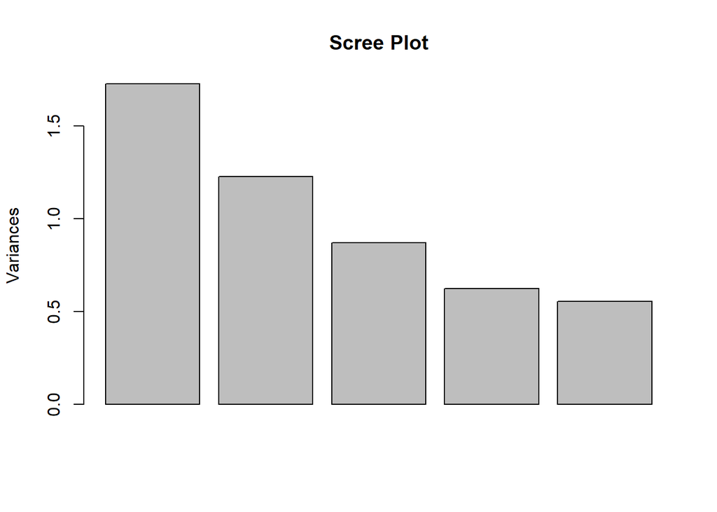

```r
# Scree plot

plot(pca_io, main = "Scree Plot")
```

The scree plot for PCA on ‘mat_df_io’ shows that highest variance is shown by PC1, after which the curve starts to slope downward. It appears to level off a little bit after the fourth Principal Component. This “elbow” point can be a litle tough to point out for the Scree Plot shown.

We proceed to extract the Principal Components into a data frame and append the target variable to it which will then be used for model construction and evaluation.

```
##          PC1        PC2          PC3         PC4        PC5 RiskLevel
## 1 -1.4739927 -1.6918258  0.285468757 -1.44821015 -0.8983098 high risk
## 2 -2.1329006 -0.2550661 -1.254922432 -0.71985464 -0.4664672 high risk
## 3  0.3922219 -1.4775497 -0.001230953  0.04035037  0.5804389 high risk
```

We observe the five Principal Components selected along with the target variable in the final prepared data set of ‘mat_df_io’ called ‘final_io’.

Lastly, We proceed to perform PCA for ‘mat_df_im’ (having Imputed Missing values).

```r
# Performing Principal Component Analysis

pca_im <- prcomp(mat_df_im[,-6], center = FALSE, scale. = FALSE)

# Inspecting summary of PCA

summary(pca_im)
```

```
## Importance of components:
##                           PC1    PC2    PC3    PC4    PC5
## Standard deviation     1.2775 1.0870 0.9392 0.8158 0.7993
## Proportion of Variance 0.3264 0.2363 0.1764 0.1331 0.1278
## Cumulative Proportion  0.3264 0.5627 0.7391 0.8722 1.0000
```

From `summary` function, we observe that after performing PCA on ‘mat_df_im’ (having Imputed Missing values), PC1 explains most variance (32.6% in this case) out of all the components. It is lesser than both previous cases probably because in ‘mat_df_im’ random values were replaced with NA and then were imputed with median. This could have led to values that previously contributed to higher variance to be no longer present. Wanting to retain data that explains at least 95% of variance, we will consider all five Principal Components in predicting the target variable.

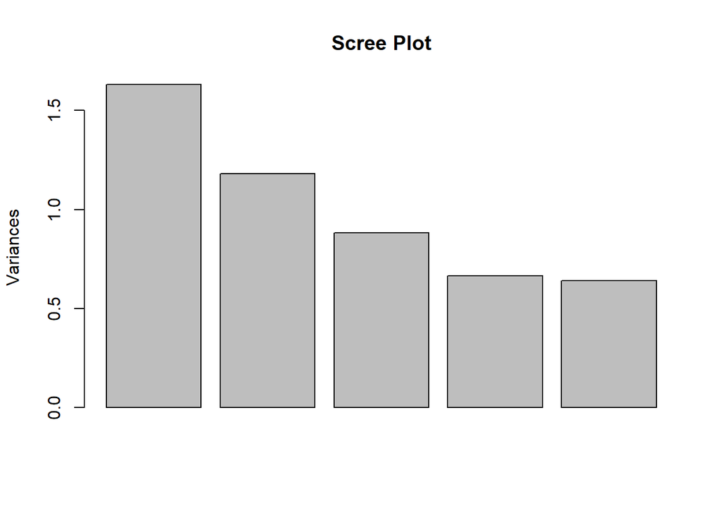

```r
# Scree plot

plot(pca_im, main = "Scree Plot")
```

The scree plot for PCA on ‘mat_df_im’ shows that highest variance is shown by PC1, after which the curve starts to slope downward. It appears to level off a little bit after the fourth Principal Component. This “elbow” point can be a litle tough to point out for the Scree Plot shown.

We proceed to extract the Principal Components into a data frame and append the target variable to it which will then be used for model construction and evaluation.

```
##          PC1       PC2         PC3        PC4         PC5 RiskLevel
## 1 -1.5167464 -1.834834  0.62167006 -1.4365594 -0.82537090 high risk
## 2 -2.2936534 -0.245627 -1.06947041 -0.8843832 -0.50011419 high risk
## 3 -0.1835656 -1.341269 -0.07102453  0.3778379 -0.02812033 high risk
```

We observe the five Principal Components selected along with the target variable in the final prepared data set of ‘mat_df_im’ called ‘final_im’.

# 6 Model Construction

## 6.1 Creation of Training and Validation Subsets

We will split each of the three data frames, final_uniq, final_io and final_im into 75%/25% subsets, where 75% will be used for training the data and 25% will be used for validation.

Before splitting the data, within each of the three data frames, we will check proportions of classes of the target variable. We do this to check if any class is dominant over the others.

```
## Proportion of target variable in final_uniq:
```

```
##
##  low risk  mid risk high risk
## 0.5176991 0.2345133 0.2477876
```

```
## Proportion of target variable in final_io:
```

```
##
##  low risk  mid risk high risk
## 0.5176991 0.2345133 0.2477876
```

```
## Proportion of target variable in final_im:
```

```
##
##  low risk  mid risk high risk
## 0.5176991 0.2345133 0.2477876
```

We can see that low risk alone makes half the observations, while mid and high risk combined make the other half of the data set. To avoid any class imbalance in the training and validation data sets, we will use `createDataPartition` function from `caret` package to ensure stratified sampling.

Now that we have ensured similar proportions of classes in training and validation data sets, we proceed to build our classification models.

## 6.2 1st Classification Model: k-Nearest Neighbours (kNN)

We proceed with building our 1st classification model kNN. Generally, the starting value of k is assumed to be the square root of observations (21 in this case). Using the `caret` package, we will explicitly state value of k as 21.

We will build kNN models for all three data sets (Original dataset, Imputed Outliers dataset, and Imputed Missing values data set).

```r
set.seed(555)

# Building kNN model on data extracted from 'final_uniq' (Original dataset)

tune_grid <- expand.grid(k = c(21))

uniq_kNN_model <- train(RiskLevel ~ . ,
                        data = uniq_train,
                        method = "knn",
                        tuneGrid = tune_grid)


# Building kNN model on data extracted from 'final_io' (Imputed Outliers dataset)

tune_grid <- expand.grid(k = c(21))

io_kNN_model <- train(RiskLevel ~ . ,
                      data = io_train,
                      method = "knn",
                      tuneGrid = tune_grid)

# Building kNN model on data extracted from 'final_im' (Imputed Missing values dataset)

tune_grid <- expand.grid(k = c(21))

im_kNN_model <- train(RiskLevel ~ . ,
                      data = im_train,
                      method = "knn",
                      tuneGrid = tune_grid)
```

We will later test different values of k to determine which value gives the best accuracy.

## 6.3 2nd Classification Model: Logistic Regression

Next, we will proceed with building Logistic regression models.

```r
# Building logistic regression model of data from 'final_uniq'

  uniq_LR_model <- multinom(RiskLevel ~ PC1 + PC2 + PC3 + PC4 + PC5, data = uniq_train)

# Building logistic regression model of data from 'final_io'

  io_LR_model <- multinom(RiskLevel ~ ., data = io_train)

# Building logistic regression model of data from 'final_im'

  im_LR_model <- multinom(RiskLevel ~ PC1 + PC2 + PC3 + PC4 + PC5, data = im_train)
```

We used `nnet` package to train multi-nomial logistic regression models for the three data sets.

## 6.4 3rd Classification Model: Decision Tree

Next, we proceed with building decision tree models for the three data sets.

```r
# Building decision tree model of data from 'final_uniq'

uniq_DT_model <- rpart(RiskLevel ~ ., data = uniq_train, method = "class")

# Building decision tree model of data from 'final_io'

io_DT_model <- rpart(RiskLevel ~ ., data = io_train, method = "class")

# Building decision tree model of data from 'final_im'

im_DT_model <- rpart(RiskLevel ~ ., data = im_train, method = "class")
```

We trained decision tree models using the `rpart` package.

## 6.5 Appropriateness of Chosen Models For Given Data

1. k-Nearest Neighbours: kNN is a non-parametric algorithm. It does not make any assumptions about the underlying data distribution or the relationship between the predictors and the target variable. This makes it well-suited for capturing complex, non-linear patterns in the data. During data exploration, we saw that the correlations between predictor features and target variable are in the range of -0.11 to -0.48. Since they are weak to moderate, kNN will perform well because it does not assume any specific form for the relationship between predictors and the target. Additionally, the data set had many duplicates and they had to be removed so we ended up with a smaller dataset which ultimately is for kNN as it is computationally expensive for larger datasets.
2. Logistic Regression: While Logistic Regression assumes a linear relationship between the predictors and the log-odds of the target, it can still perform reasonably well with moderate correlations. It further provides probabilistic outputs, which can be helpful for understanding the likelihood of different risk levels, even if the relationships between features and target are complex.
3. Decision Trees: Decision Trees are particularly good at handling non-linear relationships because they split the data based on feature values in a hierarchical manner. This allows them to model complex interactions and non-linear patterns between features and the target.

# 7 Model Evaluation

## 7.1 Evaluation of Fit of Models with Holdout Method

We proceed with model evaluation using Holdout method.

We will evaluate our models based on Accuracy, Recall (sensitivity) of high risk, and macro-averaged F1 score. It is important to determine Recall (sensitivity) for high risk cases because incorrectly identified high risk cases would have significant consequences. Regarding F1 score, we will calculate the macro-averaged F1-score which treats all classes equally and doesn’t let the majority class (low risk in this case) dominate the performance metric.

### 7.1.1 Holdout Method for kNN

First, we will start with evaluating kNN models built on the three data sets (Original, Imputed Outliers, and Imputed Missing values data set).

```
## Confusion matrix based on data from final_uniq:
```

```
##            Actual
## Predicted   low risk mid risk high risk
##   low risk        51       15         2
##   mid risk         3        3         3
##   high risk        4        8        23
```

```
## Confusion matrix based on data from final_io:
```

```
##            Actual
## Predicted   low risk mid risk high risk
##   low risk        56       21        11
##   mid risk         2        4         0
##   high risk        0        1        17
```

```
## Confusion matrix based on data from final_im:
```

```
##            Actual
## Predicted   low risk mid risk high risk
##   low risk        50       17        11
##   mid risk         3        4         2
##   high risk        5        5        15
```

Based on confusion matrices created, we notice that kNN correctly predicts low-risk values very well. However it does not predict mid-risk values as good. We will compare the models built by kNN on the three different data sets based on accuracy, recall (high risk), and macro-averaged F1 score:

```
##                                   Accuracy Recall_High_Risk Macro_averaged_F1
## Original dataset (no imputations)  68.75 %          82.14 %           57.04 %
## Imputed Outliers dataset           68.75 %          60.71 %           58.54 %
## Imputed Missing values dataset     61.61 %          53.57 %              51 %
```

We notice that while Accuracy of Original data set kNN model and Imputed Outliers kNN model is the same, the macro-averaged F1 score of Imputed Outliers kNN model is only slightly higher than the Original model, indicating that when classes are given equal importance, overall performance of Imputed Outliers model is better.

Regarding recall (sensitivity), we see that the original data set model performs the best out of the three in capturing true positive cases of high risk (out of true positive and false negatives). Further, the Imputed Missing values data set model performs the lowest in all three metrics, This could probably be because introducing random missing data and imputing it might have changed the original distribution of the data, which impacted the model’s performance. The imputed values probably do not represent the true distribution well.

Thus, the kNN model performs best with the original dataset, where it correctly identifies high-risk cases effectively. Imputation strategies, especially for missing values, may have negatively impacted the model’s performance.

### 7.1.2 Holdout Method: Logistic Regression

Next, we will compare logistic regression models for holdout method and compare accuracy and precision metrics.

```
## Confusion matrix based on data from final_uniq:
```

```
##            Actual
## Predicted   low risk mid risk high risk
##   low risk        55       16         7
##   mid risk         3        0         0
##   high risk        0       10        21
```

```
## Confusion matrix based on data from final_io:
```

```
##            Actual
## Predicted   low risk mid risk high risk
##   low risk        57       21        10
##   mid risk         1        3         0
##   high risk        0        2        18
```

```
## Confusion matrix based on data from final_im:
```

```
##            Actual
## Predicted   low risk mid risk high risk
##   low risk        49       18        10
##   mid risk         0        0         0
##   high risk        9        8        18
```

We notice that similar to kNN, logistic regression models correctly predict low-risk very well. We see that Logistic Regression models fail to correctly predict mid risk values completely in the Original and Imputed Missing values data set. Thus, since calculating the macro-averaged F1 score won’t make sense, we will only calculate Accuracy and Recall for high risk for the logistic regression models.

We will now compare Accuracy and Recall for these three data sets:

```
##                                   Accuracy Recall_High_Risk
## Original dataset (no imputations)  67.86 %             75 %
## Imputed Outliers dataset           69.64 %          64.29 %
## Imputed Missing values dataset     59.82 %          64.29 %
```

We notice that the Imputed Outliers Logistic Regression model shows highest accuracy out of the three. But at the same time, the original data set model shows highest recall for high risk. The Imputed Missing values data set shows lowest performance in both metrics out of the three.

According to me, the Original data set logistic regression model performs the best out of the three since its accuracy is only slightly less than Imputed outliers model, while its recall is highest. It seems imputation of outliers and missing values has negatively impacted the performance.

### 7.1.3 Holdout Method: Decision Tree

We proceed with applying holdout method for decision trees and comparing performance on the three data sets.

```
## Confusion matrix based on data from final_uniq:
```

```
##            Actual
## Predicted   low risk mid risk high risk
##   low risk        41       13         7
##   mid risk        13        5         5
##   high risk        4        8        16
```

```
## Confusion matrix based on data from final_io:
```

```
##            Actual
## Predicted   low risk mid risk high risk
##   low risk        50       20         6
##   mid risk         5        3         4
##   high risk        3        3        18
```

```
## Confusion matrix based on data from final_im:
```

```
##            Actual
## Predicted   low risk mid risk high risk
##   low risk        44       17         5
##   mid risk        10        4         7
##   high risk        4        5        16
```

We notice that Decision Tree models correctly predict low risk very well, but it doesn’t predict mid-risk values well. We will compare Accuracy, Recall for high risk and macro-averaged F1 score using decision trees on all three data sets.

```
##                                   Accuracy Recall_High_Risk Macro_averaged_F1
## Original dataset (no imputations)  55.36 %          57.14 %           48.82 %
## Imputed Outliers dataset           63.39 %          64.29 %           53.22 %
## Imputed Missing values dataset     57.14 %          57.14 %           49.46 %
```

We see that for Decision Tree models, the Imputed Outliers model performs better than the other two in all performance metrics. This implies that Imputing Outliers was beneficial for decision tree models. The Imputed Missing values performs better than the Original data set model for Decision trees.

## 7.2 Evaluation with k-fold Cross-validation & Hyperparameter Tuning

We proceed with using k-fold cross validation and tuning hyperparameters. It will be helpful as the low number of observations in our data set won’t be enough to train the models sufficiently. By testing the model on multiple subsets, and tuning hyperparameters where applicable (kNN and decision tree), the performance should likely improve.

### 7.2.1 kNN model (Hyperparameter tuning & Cross-validation)

For kNN, we will first find optimal value of k by plotting a graph of different k values (1-30) vs Accuracy. After that we will apply cross validation with the optimal value of k to build the model. This will be done for all the three data sets (Original data set, Imputed Outliers data set, and Imputed Missing values data set).

We start with the Original data set:

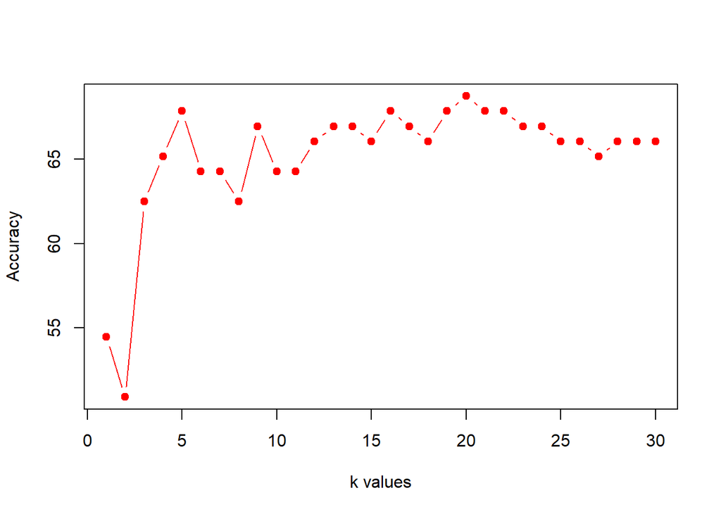

We can observe that for k = 20, the model gives best accuracy. We will thus use k = 20 while building kNN model for the original data set.

Next, we will find value of k for Imputed Outliers data set:

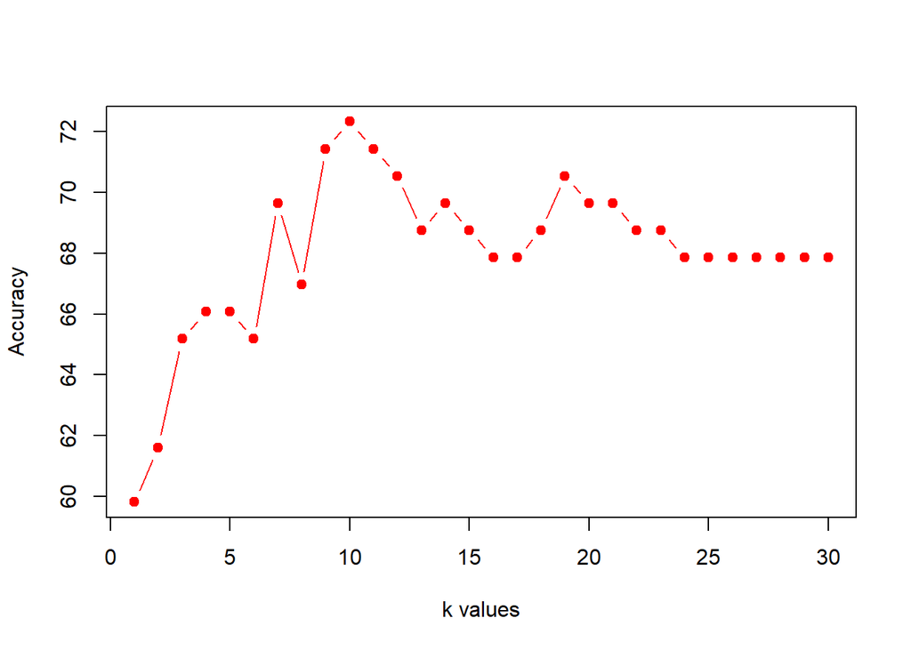

We can observe that for k = 10, the model gives best accuracy. We will thus use k = 10 while building kNN model for the Imputed Outliers data set.

Next, we find optimal value of k for Imputed Missing values data set:

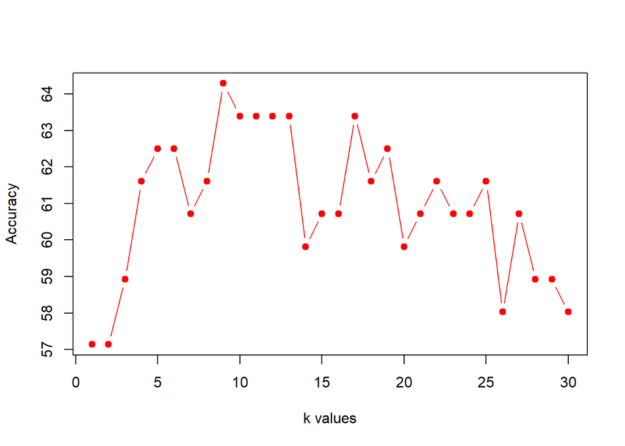

We can observe that for k = 9, the model gives best accuracy. We will thus use k = 9 while building kNN model for the Imputed Missing values data set.

We proceed with using cross validation (using 10 folds) for all three data sets based on the k values found in above graphs. Further, we will calculate Accuracy, Recall for high risk and macro-averaged F1 score metrics for the three kNN models.

```
## Performance metrics before cross validation & hyperparameter tuning:
```

```
##                                   Accuracy Recall_High_Risk Macro_averaged_F1
## Original dataset (no imputations)  68.75 %          82.14 %           57.04 %
## Imputed Outliers dataset           68.75 %          60.71 %           58.54 %
## Imputed Missing values dataset     61.61 %          53.57 %              51 %
```

```
## Performance metrics after cross validation & hyperparameter tuning:
```

```
##                                   Accuracy Recall_High_Risk Macro_averaged_F1
## Original dataset (no imputations)  67.86 %          82.14 %           54.86 %
## Imputed Outliers dataset           70.54 %          67.86 %            63.1 %
## Imputed Missing values dataset     63.39 %          67.86 %           55.88 %
```

We observe that for Imputed Outliers data set, the accuracy improved after cross validation and using optimal k-value.

For the Original data set that had outliers, the accuracy decreased. This can be because outliers affect the performance of k-Nearest Neighbors (kNN). And after tuning and cross validation, this was magnified and ultimately affected its performance. Cross-validation exposed issues that were masked in the holdout method. On the other hand, the recall for Original model reamins the highest.

For Imputed Missing values data set we can see an improvement in overall accuracy, with precision of most classes increasing as well.

We an thus say that for kNN, tuning hyperparameters and using k-fold cross validation was beneficial for Imputed Outliers and Imputed Missing values data set. But still I consider the Original kNN model to be the best even after cross validation, owing to the fact that it has hgiest recall, and only slightly lesser accuracy and F1 score than others.

### 7.2.2 Logistic Regression model (Cross-validation)

We will proceed with applying cross-validation to the logistic regression models. We will only be comparing Accuracy and Recall for high risk for the three models.

```
## Accuracy and Recall (for high risk) before cross validation & hyperparameter tuning:
```

```
##                                   Accuracy Recall_High_Risk
## Original dataset (no imputations)  67.86 %             75 %
## Imputed Outliers dataset           69.64 %          64.29 %
## Imputed Missing values dataset     59.82 %          64.29 %
```

```
## Accuracy and Recall (for high risk) after cross validation & hyperparameter tuning:
```

```
##                                   Accuracy Recall_High_Risk
## Original dataset (no imputations)  68.75 %          85.71 %
## Imputed Outliers dataset           63.39 %          57.14 %
## Imputed Missing values dataset      62.5 %             75 %
```

We observe that after cross validation of Logistic Regression models, the Performance metrics of both Original model and Imputed Missing values model increases, while that of Imputed Outliers decreases.

We can thus see that before and after cross validation, the Original data set logistic regression model perfroms the best out of the three models.

### 7.2.3 Decision Tree model (Hyperparameter tuning & Cross-validation)

Next, we proceed with applying cross-validation to decision tree models and tune its hyperparameters. We will optimize the model by finding and using optimal values for number of levels in the tree, and using 10 fold cross validation on all three models.

```
## Accuracy and Recall (for high risk) before cross validation & hyperparameter tuning:
```

```
##                                   Accuracy Recall_High_Risk
## Original dataset (no imputations)  55.36 %          57.14 %
## Imputed Outliers dataset           63.39 %          64.29 %
## Imputed Missing values dataset     57.14 %          57.14 %
```

```
## Accuracy and Recall (for high risk) after cross validation & hyperparameter tuning:
```

```
##                                   Accuracy Recall_High_Risk
## Original dataset (no imputations)  55.36 %          57.14 %
## Imputed Outliers dataset           65.18 %          64.29 %
## Imputed Missing values dataset     57.14 %          57.14 %
```

We observe that tuning limited hyperparameters and applying 10 fold cross validation on the Decision Tree models doesn’t improve the performance to a great extent. In fact, it only slightly increases the Accuracy for the Imputed Outliers data set.

We can thus say that after before and after cross validation, the Imputed Outliers Decision Tree model performs best out of the others.

## 7.3 Comparison of Models and Interpretation

We will compare Accuracy and Recall of high risk of all three chosen ML models for the three data sets (after k fold cross validation was done).

```
##                                   AccuracykNN AccuracyLR AccuracyDT
## Original dataset (no imputations)     67.86 %    68.75 %    55.36 %
## Imputed Outliers dataset              70.54 %    63.39 %    65.18 %
## Imputed Missing values dataset        63.39 %     62.5 %    57.14 %
```

```
##                                   Recall_High_Risk_kNN Recall_High_Risk_LR
## Original dataset (no imputations)              82.14 %             85.71 %
## Imputed Outliers dataset                       67.86 %             57.14 %
## Imputed Missing values dataset                 67.86 %                75 %
##                                   Recall_High_Risk_DT
## Original dataset (no imputations)             57.14 %
## Imputed Outliers dataset                      64.29 %
## Imputed Missing values dataset                57.14 %
```

Comparing Recall (sensitivity), we can say that the Original data set logistic regression model performed the best out of all other models. The Original kNN model showed high recall for high risk cases as well. Recall being an important performance metric in our case, I would consider the Original logistic regression model to be the best overall, because even though it has slightly lower accuracy, accuracy doesn’t take into account weights of each class and for our data sets low risk cases dominated in the training and validation data sets, which might influence or mask performnace of other classes.

# 8 Model Tuning & Performance Improvement

## 8.1 Use of Bagging with Homogeneous Learners

Owing to the low performance of Decision Tree models seen when comparing different models, we will see if using bagging with Decision Tree models improves it’s performance.

We won’t use bagging with kNN because bagging aims to improve model performance by averaging predictions from multiple models trained on different subsets of the data. As kNN is inherently an instance-based learner and does not produce a model in the conventional sense, bagging does not offer significant benefits.

Regarding Logistic regression, it handles variance well by itself. As bagging helps with models that have high variance the benefits of bagging would be very limited with logistic regression.

Since Decision Trees are high variance models, bagging can reduce overfitting and improve stability and performance of Decision Trees.

```
## Accuracy and Recall (for high risk) after cross validation & hyperparameter tuning:
```

```
##                                   Accuracy Recall_High_Risk
## Original dataset (no imputations)  55.36 %          57.14 %
## Imputed Outliers dataset           65.18 %          64.29 %
## Imputed Missing values dataset     57.14 %          57.14 %
```

```
## Accuracy and Recall (for high risk) after bagging:
```

```
##                                   Accuracy Recall_High_Risk
## Original dataset (no imputations)  58.04 %          67.86 %
## Imputed Outliers dataset           64.29 %          67.86 %
## Imputed Missing values dataset     58.04 %             50 %
```

## 8.2 Construction of Ensemble Model as a Function

Next, we proceed with constructing an ensemble model as a function. This ensemble function will be able to predict RiskLevels by considering the mode of predicted classes by the three models for each new instance.

```r
# Creating functions to calculate mode

  get_mode <- function(x) {
  uniq_x <- unique(x)
  uniq_x[which.max(tabulate(match(x, uniq_x)))]
  }

# Creating ensemble function

hetero_ensemble <- function(newdata, model1, model2, model3){

  predicted_labels <- c()

  for(i in 1:nrow(newdata)){
    newdata <- newdata[,-6]
    kNN_pred <- predict(model1, newdata = newdata[i,])
    LR_pred <- predict(model2, newdata = newdata[i,])
    DT_pred <- predict(model3, newdata = newdata[i,])

    predictions <- c(as.character(kNN_pred), as.character(LR_pred), as.character(DT_pred))

    mode_pred <- get_mode(predictions)

    predicted_labels <- c(predicted_labels, mode_pred)

    }

  ## returning majority vote to determine the final prediction from the individual
  ## predictions

  predicted_labels <- factor(predicted_labels, levels = c("low risk", "mid risk", "high risk"))

  return((predicted_labels))

}
```

We created an ensemble function that takes 4 parameters - new data, the kNN model, logistic regression model, and decision tree model. Using these, it predicts the target variable.

## 8.3 Application of Ensemble to make a Prediction

```r
# Predicting target variable for using ensemble data extracted from Original data set

uniq_ensemble_pred <- hetero_ensemble(uniq_val, uniq_kNN_cv, uniq_LR_cv, uniq_DT_bag)

# Predicting target variable for using ensemble data extracted from Imputed Outliers data set

io_ensemble_pred <- hetero_ensemble(io_val, io_kNN_cv, io_LR_cv, io_DT_bag)

# Predicting target variable for using ensemble data extracted from Imputed Missing values data set

im_ensemble_pred <- hetero_ensemble(im_val, im_kNN_cv, im_LR_cv, im_DT_bag)
```

## 8.4 Comparison of Ensemble to Individual Models

We proceed to compare ensemble to individual models:

```
## Accuracy and Recall (for high risk) of three individual models after cross validation & hyperparameter tuning:
```

```
##                                   AccuracykNN AccuracyLR AccuracyDT
## Original dataset (no imputations)     67.86 %    68.75 %    55.36 %
## Imputed Outliers dataset              70.54 %    63.39 %    65.18 %
## Imputed Missing values dataset        63.39 %     62.5 %    57.14 %
```

```
##                                   Recall_High_Risk_kNN Recall_High_Risk_LR
## Original dataset (no imputations)              82.14 %             85.71 %
## Imputed Outliers dataset                       67.86 %             57.14 %
## Imputed Missing values dataset                 67.86 %                75 %
##                                   Recall_High_Risk_DT
## Original dataset (no imputations)             57.14 %
## Imputed Outliers dataset                      64.29 %
## Imputed Missing values dataset                57.14 %
```

```
## Accuracy and Recall (for high risk) of ensemble:
```

```
##                                   Accuracy Recall_High_Risk Macro_averaged_F1
## Original dataset (no imputations)  68.75 %          82.14 %           57.27 %
## Imputed Outliers dataset           71.43 %          71.43 %           64.22 %
## Imputed Missing values dataset      62.5 %          67.86 %           53.19 %
```

We observe that the ensemble model performed with better or at par accuracy than all models for almost all data sets. Within the ensemble models created, the Original model has higher recall while Imputed Outliers has higher accuracy. I would consider the Original data set ensemble model best out of all three due to higher recall metric at the cost of slightly lower accuracy metric.

We further see that the ensemble shows high recall, though the Original data set logistic regression model for recall (for high risk) still performs the best. (As identified earlier when comparing all models with each other)

Overall, we can conclude that for the maternal health risk data set: 1. Original data set Logistic regression model performed best for Recall (fo high risk cases) 2. Imputed outliers ensemble model performed with highest accuracy out of all models and data sets.

In a practical setting, I would employ the Original data set logistic regression model since I consider recall (for high risk) a more important performance metric than accuracy based on our data set, because our dataset has majority low risk cases and training on them might have influenced performance of models on mid and high risk cases.